# Mini Project 3

Sophie Li, Rocio Jaime

November 15, 2017

# The Popularity of Sequels Over the Decades

## Using SQL and the imdb database

As the holidays roll in, movie trailers become ubiquitious, advertising to many families who include a visit to their nearby theaters as a seasonal tradition. Normally the setlist of films includes a rom-com, a holiday themed comedy, and some variation of a sequel. The question we look to answer with our data is: Have the frequency of sequels/remakes/spinoffs increased over the decades?

```r
library(mdsr)
library(RMySQL)
```

First, we wrote an SQL query to get all movies (at least 90 minutes long, to account for cartoon shorts classified as ‘movies’) with sequels, remakes, or spinoffs. We chose to not look at reboots, as the IMDB database considered any movie based on any previous media (including books and plays) as a ‘reboot’.

```r
db <- dbConnect_scidb(dbname = "imdb")

#Gets info on sequels, remakes, and spinoffs
#Uses indexes on type_ids
sequel_info <- db %>%
  dbGetQuery("SELECT ml.movie_id, t.title, mi.info AS original_runtime, ml.linked_movie_id AS sequel_id, t2.title AS sequel_title, mi2.info AS sequel_runtime, ml.link_type_id, t.production_year AS original_year, t2.production_year AS sequel_year
FROM movie_link ml
JOIN title t ON t.id = ml.movie_id
JOIN title t2 ON t2.id = linked_movie_id
JOIN movie_info mi ON mi.movie_id = ml.movie_id
JOIN movie_info mi2 ON mi2.movie_id = ml.linked_movie_id
WHERE ml.link_type_id IN (2, 4, 12)
    AND t.kind_id = 1
  AND mi.info_type_id = 1
  AND mi2.info_type_id = 1
  AND mi.info > 89
  AND mi2.info > 89;
")
```

Then, we retrieved the box-office gross for all movies (this is a separate query, as it involved text cleaning due to the inconsistent format of the data in the database)

```r
#gets gross of movies (max cumulative gross in USA only, due to constraints w/ format of data)
gross <- db %>%
  dbGetQuery('SELECT mi.movie_id, mi.info AS gross
             FROM movie_info mi
             WHERE mi.info_type_id = 107;
             ') %>%
  filter(grepl('\\$', gross)) %>%
  filter(grepl('\\(USA)', gross)) %>%
  mutate(gross = gsub('\\s.*', '', gross)) %>%
  mutate(gross = gsub('\\D', '', gross)) %>%
  mutate(gross = as.numeric(gross)) %>%
  group_by(movie_id) %>%
  summarize(max_gross = max(gross)) %>%
  arrange(desc(max_gross))
```

Next, we filtered so our data only contained original movies in the title column, added a decade column, joined the gross tbl, and removed duplicate/alternate versions. Finally, we created a function to find the top 10 grossing original movies with sequels/remakes/spinoffs for each decade in order to prepare the data for our visualization.

```r
#filters for duplicates (so only original movie shows up, w/ sequels linking to it)
#adds decade column
sequel_info <- sequel_info %>%
  filter(!(title %in% sequel_title)) %>%
  mutate(decade = 10 * floor(original_year / 10)) %>%
  select(movie_id, title, original_year, decade, sequel_title, sequel_year, link_type_id) %>%
  left_join(gross, movie_id = movie_id) %>%
  unique()

#Function that finds top 10 grossing movies
top10 <- function(data) {
  data %>%
    group_by(title) %>%
    summarize(top_movies = max(max_gross)) %>%
    arrange(desc(top_movies)) %>%
    head(10)
}

#Finds top 10 grossing movies per decade
top_movies_decade <- sequel_info %>%
  filter(!is.na(max_gross)) %>%
  group_by(decade) %>%
  do(top10(.))

#Calculates popular sequels
pop_seq <- sequel_info %>%
  filter(title %in% top_movies_decade$title & !is.na(max_gross)) %>%
  select(decade, title, original_year, sequel_title, sequel_year, link_type_id) %>%
  mutate(title = reorder(title, original_year)) %>%
  mutate(link_type_id = factor(link_type_id))
```

For our graphic below, we found the the top ten grossing movies per decade, and joined with the movie_link data to see if they had follow up films. Our movies are grouped by the decade of the original movies’ release dates, which is indicated by the black dot at the start of each line segment. The seqential dots on the line segments represent the follow up movies, which are color coded by whether they are a sequel, remake, or spinoff.

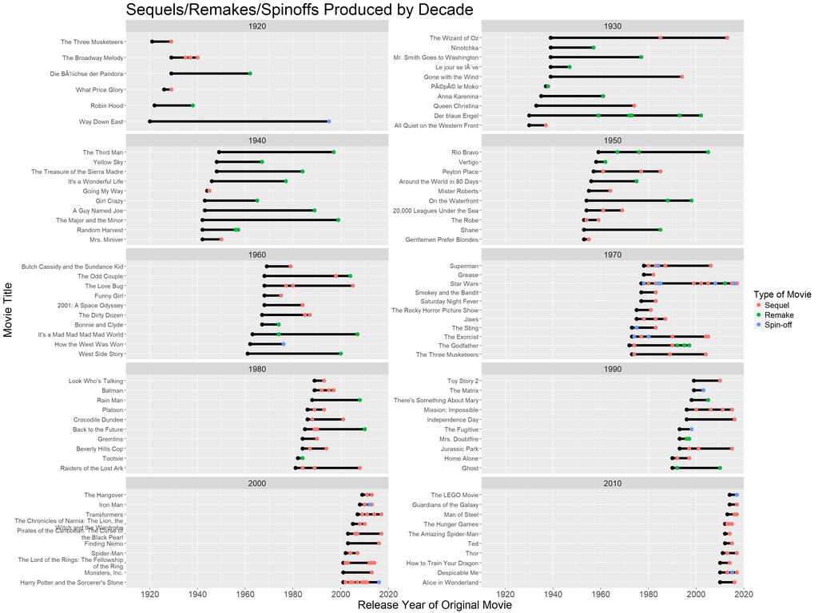

```r
ggplot(pop_seq, aes(x = original_year, y = title)) +
  geom_segment(aes(xend = sequel_year, yend = title), size = 2) +
  geom_point(size = 3) +
  geom_point(aes(x = sequel_year, y = title, color = link_type_id), size = 3) +
  labs(color = 'Type of Movie', title = "Sequels/Remakes/Spinoffs Produced by Decade", x = "Release Year of Original Movie", y = "Movie Title") +
  theme(axis.text.x = element_text(size= 15),
        axis.text.y = element_text(size = 11),
        plot.title = element_text(size = 28),
        strip.text.x = element_text(size = 14),
        legend.title = element_text(size = 16),
        legend.text = element_text(size= 14),
        axis.title.x = element_text(size = 20),
        axis.title.y = element_text(size = 20)) +
  scale_color_discrete(labels = c('Sequel', 'Remake', 'Spin-off')) +
  scale_y_discrete(labels = scales::wrap_format(40)) +
  scale_x_continuous(limits = c(1910, 2020), expand = c(0, 0)) +
  facet_wrap( ~ decade, nrow = 5, scales = "free_y")
```

When creating the graphic, we assumed that movies released more recently would not have as much sequel data, but in fact, although the segments for movies released in the 21st century are shorter, the total of follow up dots is about the same as previous decades. This means that movies released more recently have about the same amount of follow ups as other decades, but the amount of follow ups was produced in less time, meaning sequels/follow ups are becoming more frequent.This is very possibly due to money. When an original movie is well executed, members of the audience are more likely to become invested in the plot and characters, and eventually a fandom forms. If there is a large fandom for a specific film, producers can assume that a sequel for a film will have a strong turn out, bringing in more money for the franchise.It’s an easy way for film makers to make money; instead of producing brand new ideas, they can build off a story that is already popular.

Github repository: https://github.com/sophieml/sds192-mp3